# My visual data story of exploring video trends

In this data story that I have made, we are going to explore key patterns within the videos content of Chinese Tik Tok (DouYin), focusing on video duration, video likes and creator insights.

## Plot 1: Average video duration by Gender (Bar Plot)

[figure not shown]

Average video duration by Gender Plot

This bar plot is showing the average video duration by gender. The plot compares video duration by the gender of the creator/author. Each bar represents the average duration of between the male and female creators. There are total of three gender groups, male, female and they/group. However, during the observations, there are no creator that is made up by a group of people so there’s only two bars. By observing the plot, there is a significant difference in the average video duration between the male and female creator. This could be due to different factors such as the audience and contents etc.

## Plot 2: Video length by Timestamp (Scatter Plot)

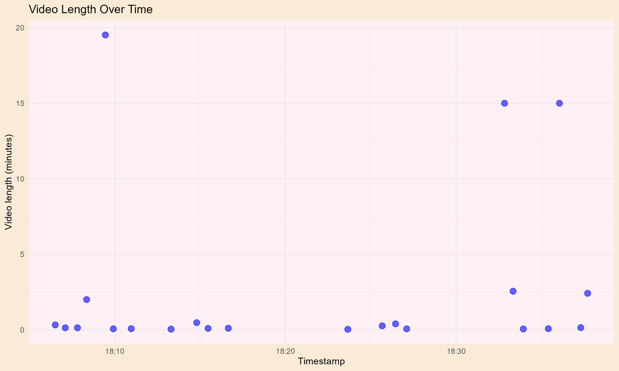

Video length by Timestamp

This scatter plot is showing the video length by time stamp. The blue dots represents the video length across various time stamps. Observing the plot, we can see that most of the dots are near to the bottom, slightly above than 0. This means that most of the videos are slightly longer than 0 seconds, which is around 10 seconds. There are a few outliers, which are longer than 10 minutes. By looking at the pattern of the dots, we could see that the outliers occurs after some of the dots. This could mean that the system of Dou Yin suggests a long video after a couple of short videos. The reason that the system does this is to keep users to be on the platform for a longer period of time. The short videos create a “snaking” behavior which build the users momentum of continuing watching the videos and the long video extends the session.

## Plot 3: Video length by Number of Videos (Scatter Plot)

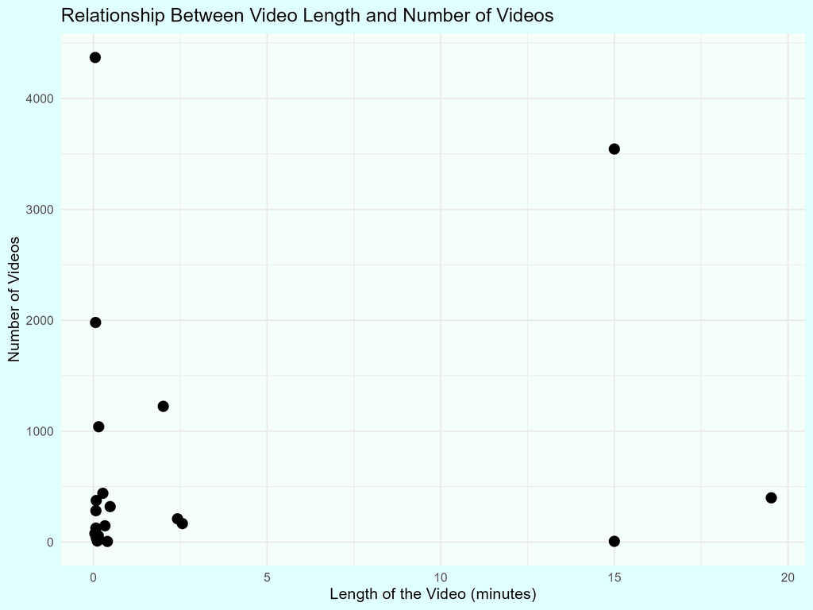

Video length by Number of Videos Plot

This scatter plot is showing the relationship between the video duration and the amount of videos posted by the creator. Each dot represents an individual video, the x-axis shows the duration of the video and the y-axis shows the amount of videos the creator have. The plot does not show clear correlation between this two variables. I always wonder if the the number of videos of may affect the duration of the video. From this plot, we can see that one of the creator have more than four thousand videos but still have videos that are shorter than five minutes. From my thought, creator with more videos may have more experience so they would create a longer video that could attract the audience. However, creator with less videos could also create a long duration video.